# Donor Profile: Spain (Autonomous authorities of)

## Transaction Volatility

Spain’s funding profile shows an average transaction amount of $219.5K across 25.3 yearly transactions, starkly contrasted by top donors averaging $2.9M and 586.9 transactions. This significant funding scale gap highlights a strategic opportunity: investing to amplify Spain’s funding volume can unlock broader impact and operational stability. The volatility in transaction timing and value further complicates programming predictability, posing risks to sustained emergency and resilience initiatives. Targeted donor investments to stabilize and scale Spain’s funding pipeline emerge as a high-leverage opportunity, enhancing collaboration effectiveness and reducing fiscal risk. We recommend prioritizing partnership strategies that increase transaction frequency and size, aligning with donor priorities for innovation and accountability. Immediate executive attention to this funding volatility can transform Spain into a reliable funding multiplier, delivering measurable returns on investment and stronger program continuity. Decision-makers should mobilize resources urgently to capitalize on this underutilized potential, ensuring Spain contributes robustly to UNHCR’s strategic goals.

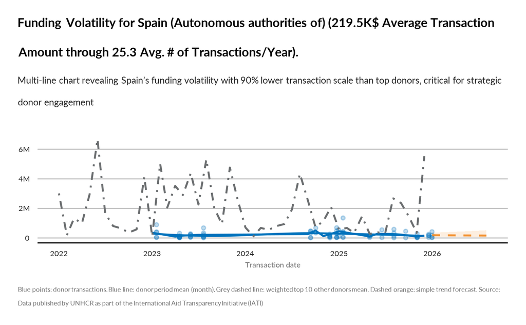

TRUE